# Week 2 Day 1 Homework

```r
library(tidyverse)
library(janitor)
library(infer)
```

# MVP

## Question 1

```r
ames <- read_csv("ames.csv") %>%
  clean_names()
```

## Question 2

Investigate the distribution of lot_area. Is the distribution roughly normal? If not, what problems do you find?

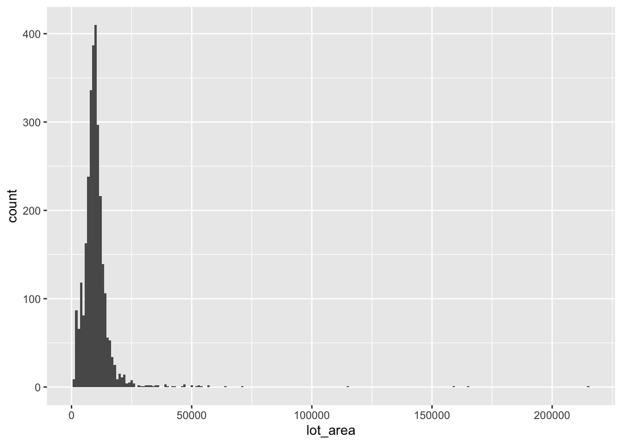

```r
ames %>%
  ggplot(aes(lot_area)) +
  geom_histogram(binwidth = 1000)
```

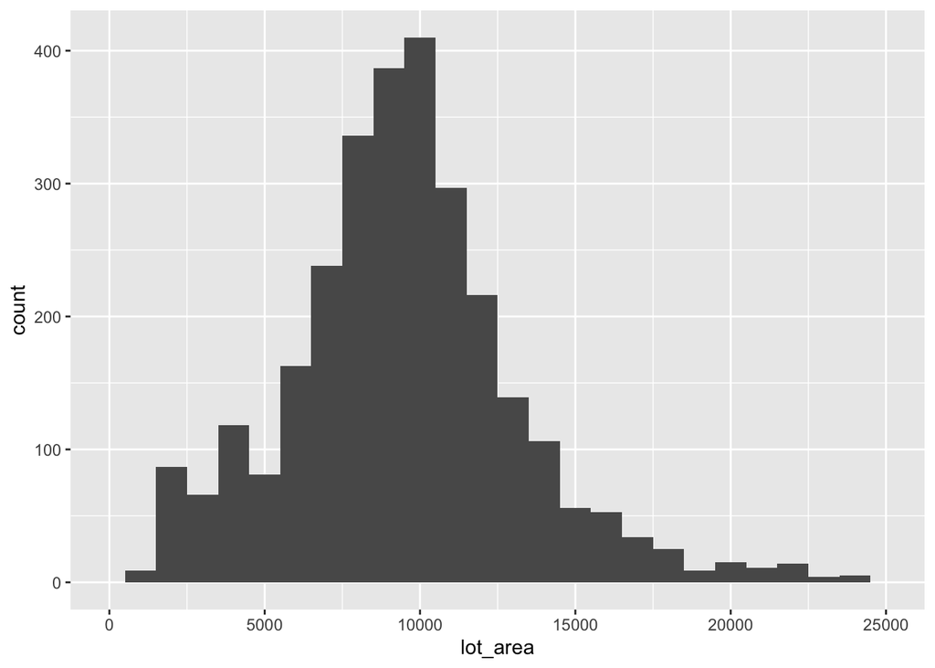

```r
ames %>%
  ggplot(aes(lot_area)) +
  geom_histogram(binwidth = 1000) +
  xlim(0, 25000)
```

There are some very high values for lot_area in the data. This is skewing the data to the right. Will be interesting to see what this looks like in a qq plot. If you zoom in on the 0 - 25000 area of the x-axis then the data doesn’t look too far from a normal distribution.

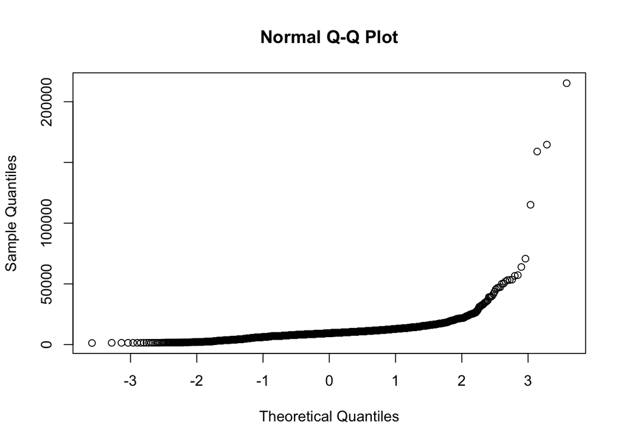

```r
qqnorm(ames$lot_area)
```

Wow this is the least linear qq plot I’ve seen so far. This data does not have a normal distribution.

## Question 3

Compute and visualise a bootstrap sampling distribution for the mean(lot_area) of the sold houses.

There are 2930 rows in the dataset. Lets try 5000 bootstrap samples and see how the computer copes

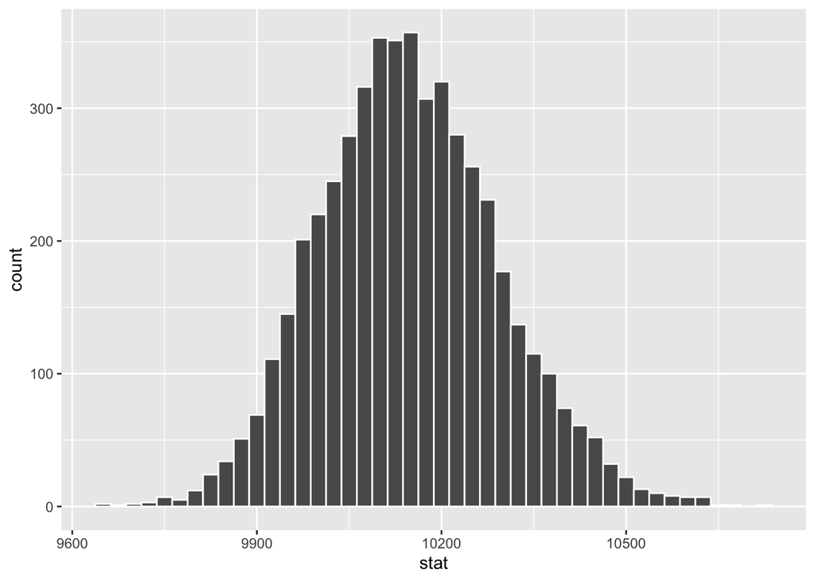

```r
mean_lot_area <- mean(ames$lot_area)

infer_resample <- ames %>%
  specify(response = lot_area) %>%
  generate(reps = 5000, type = "bootstrap") %>%
  calculate(stat = "mean")

infer_resample %>%
  ggplot(aes(stat)) +
  geom_histogram(binwidth = 25,
                 col = "white")
```

## Question 4

Use your bootstrap distribution to calculate a 95% CI for mean(lot_area), and visualise it on the distribution

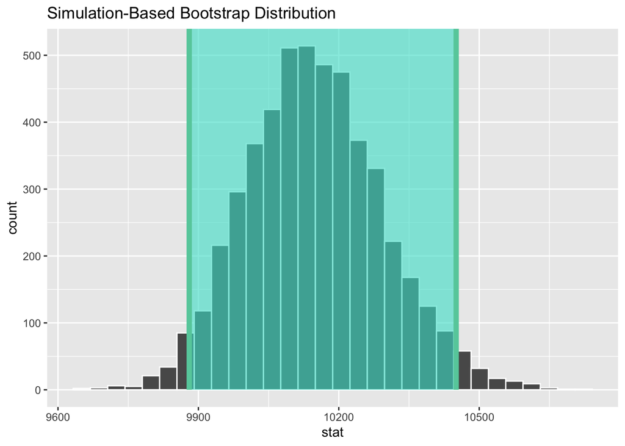

```r
infer_ci_95 <- infer_resample %>%
  get_ci(level = 0.95, type = "percentile")

infer_resample %>%
  visualise(bins = 30) +
  shade_ci(endpoints = infer_ci_95)
```

## Question 5

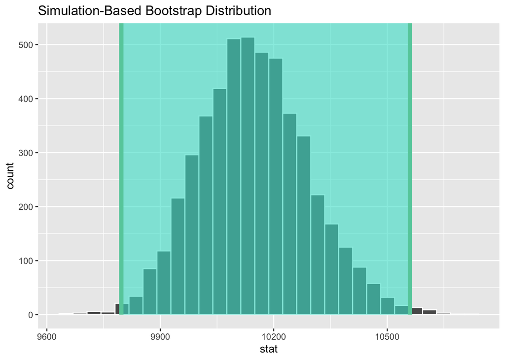

```r
infer_ci_99 <- infer_resample %>%
  get_ci(level = 0.99, type = "percentile")

infer_resample %>%
  visualise(bins = 30) +
  shade_ci(endpoints = infer_ci_99)
```

The 99% CI is broader than the 95% CI. This makes sense as the 99% confidence intervals is where you would find 99% of the data, where the 95% CI only includes 95% of the data. The limits would have to be widened to include the larger number of points.

## Question 6

Calculate the point estimate of the mean(lot_area)

```r
point_est_mean_lot_area <- mean(infer_resample$stat)

point_est_mean_lot_area
```

```
## [1] 10148.4
```

# Extension

## Question 1

Calculate a point estimate and 95% CI for the proportion of houses in the data built before 1920. Does the number of reps you use matter? [Investigate reps from 200 up to 50000, memory of your laptop permitting].

```r
prop_pre_1920 <- ames %>%
  filter(year_built < 1920) %>%
  summarise(prop_pre_1920 = n() / nrow(ames))

prop_pre_1920
```

| prop_pre_1920 |
| --- |
| 0.06006826 |

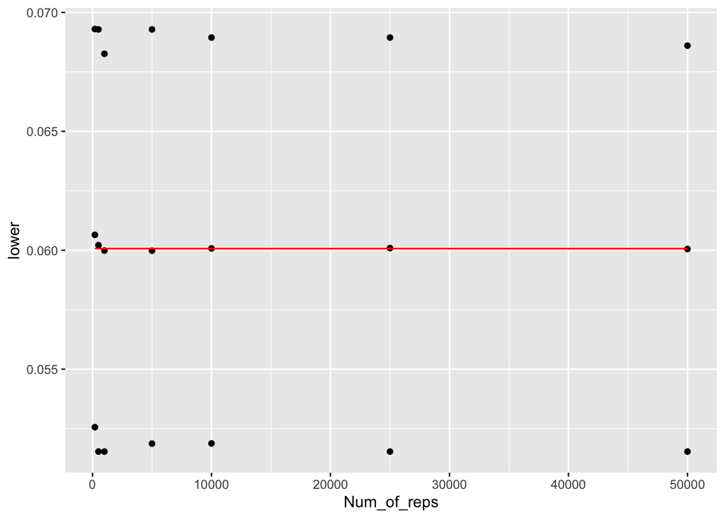

```r
ames <- ames %>%
  mutate(before_1920 = ifelse(year_built < 1920, "yes", "no"))

rep_num <- c(200, 500, 1000, 5000, 10000, 25000, 50000)

results <- tibble()

for (num_reps in rep_num) {

  bootstrap_resample <- ames %>%
  specify(response = before_1920, success = "yes") %>%
  generate(reps = num_reps, type = "bootstrap") %>%
  calculate(stat = "prop")

  ci_95 <- bootstrap_resample %>%
  get_ci(level = 0.95, type = "percentile")

  before_1920_mean <- bootstrap_resample %>%
  summarise(mean_before_1920 = mean(stat))

  one_result <- c(
    Num_of_reps = num_reps,
    lower = ci_95 %>%
      pull(lower_ci),
    upper = ci_95 %>%
      pull(upper_ci),
    before_1920_mean = before_1920_mean %>%
      pull()
  )

  results <- results %>%
    bind_rows(one_result)

}

rp <- c(200, 50000)
mn <- c(0.06006826, 0.06006826)


df <- tibble(rp, mn)


ggplot() +
  geom_point(data = results, aes(x = Num_of_reps, y = lower)) +
  geom_point(data = results, aes(Num_of_reps, upper)) +
  geom_point(data = results, aes(Num_of_reps, before_1920_mean)) +
  geom_line(data = df, aes(x = rp, y = mn), col = "red")
```